# STAT-462: Lab 5

# Markdown

```r
# Clear Workspace
rm(list=ls())

# Load libraries
library(tidyverse)
library(dplyr)
library(ggpubr)
library(Stat2Data)
library(corrplot)
library(olsrr)
library(sf)
library(tmap)
library(plotly)
library(skimr)
library(gridExtra)
library(ggExtra)
library(GGally)
```

# Q1

## Context

`PlantAdvertising.csv`, which we read in as the `Plants` data set, contains data on 200 of our company’s houseplant marketing campaigns from the last few years. Each row is one campaign. There are 200 rows and 6 variables in `Plants`. From the information given, I assume that the observational units are one particular campaign for one particular type of plant that ran at some point in the “last few years”. The goal of examining `Plants` is to gain insight on whether the amount of money we spend on different advertising media is a linear predictor of the houseplant sales for a campaign.

Something that it may be important to note is the extent of this data set. We aren’t told exactly how the data was collected, but from the background provided it sounds like this data set somehow contains information for *all campaigns* the company has run in the past few years. I’m concluding this from the fact that the company has run exactly 200 campaigns and our data set contains information on 200 campaigns:

> *“You have run 200 marketing campaigns over the last few years. For each one, you recorded…”*

```r
Plants <- read.csv("PlantAdvertising.csv") # Read in data
nrow(Plants) # Display number of rows
```

```
## [1] 200
```

If our goal is to gain insight on how our recent campaigns performed then the `Plants` data set might actually be the entire population of interest, in which case inference about the population is unnecessary because we have direct access to it. For the purposes of completing the lab, and considering the possibility of my misinterpretation of the data’s background, we continue from here treating our data set as a representative *sample* of our population.

For each campaign we have numerical data on how much money was spent in thousands of US dollars on TV, radio, and newspaper advertisements, contained under the `TV`, `Radio`, and `Newspaper` columns respectively, how many houseplants were sold in thousands of plants, `Sales`, the percentage popularity of the houseplant at that time, `Plant_Popularity` (I’m unsure exactly how popularity was measured), and the typical height of the houseplant in inches, `Plant_Height_in`. Below is an output showing the distribution and summary statistics of each variable. `TV` and `Radio` appear to have approximately uniform distributions. `Newspaper` and `Sales` seem positively skewed.

```r
# Some of the column headers weren't read in correctly
names(Plants)
```

```
## [1] "ï..Plant_Popularity" "Plant_Height_in"     "Radio"
## [4] "TV"                  "News....paper"       "Sales"
```

```r
# We'll fix them here
names(Plants)[1] <- "Plant_Popularity"
names(Plants)[5] <- "Newspaper"

# Show a summary of the data
skim(Plants)
```

Data summary

| Name | Plants |
| --- | --- |
| Number of rows | 200 |
| Number of columns | 6 |
| _______________________ |  |
| Column type frequency: |  |
| numeric | 6 |
| ________________________ |  |
| Group variables | None |

**Variable type: numeric**

| skim_variable | n_missing | complete_rate | mean | sd | p0 | p25 | p50 | p75 | p100 | hist |
| --- | --- | --- | --- | --- | --- | --- | --- | --- | --- | --- |
| Plant_Popularity | 0 | 1 | 33.97 | 7.72 | 16.7 | 28.37 | 33.15 | 40.10 | 50.4 | ▃▇▇▇▃ |
| Plant_Height_in | 0 | 1 | 49.62 | 37.99 | 1.0 | 14.75 | 41.00 | 84.25 | 120.0 | ▇▅▃▃▅ |
| Radio | 0 | 1 | 23.26 | 14.85 | 0.0 | 9.97 | 22.90 | 36.52 | 49.6 | ▇▆▆▆▆ |
| TV | 0 | 1 | 147.04 | 85.85 | 0.7 | 74.38 | 149.75 | 218.82 | 296.4 | ▇▆▆▇▆ |
| Newspaper | 0 | 1 | 30.55 | 21.78 | 0.3 | 12.75 | 25.75 | 45.10 | 114.0 | ▇▆▃▁▁ |
| Sales | 0 | 1 | 14.02 | 5.22 | 1.6 | 10.38 | 12.90 | 17.40 | 27.0 | ▁▇▇▅▂ |

I imagine that different types of plants have different prices, so the price of a certain type of plant could be a confounding variable impacting sales. It’s unclear whether these campaigns took place during overlapping intervals of time. If so, there might be a possibility that the sales in the campaigns are not independent of each other, perhaps one campaign’s sales went down because the company’s customers were more attracted to the houseplant advertised in another simultaneous campaign. We’ll keep this in mind as we continue our analysis.

## EDA

```r
# Another brief look at the Data
head(Plants)
```

```
##   Plant_Popularity Plant_Height_in Radio    TV Newspaper Sales
## 1             35.5              32  41.3 151.5      58.5  18.5
## 2             46.8              29  28.9 273.7      59.7  20.8
## 3             26.8              91  32.8  57.5      23.5  11.8
## 4             34.3              61  20.3  75.3      32.5  11.3
## 5             28.9               6  10.8  75.5       6.0   9.9
## 6             29.4               8  18.1 172.5      30.7  14.4
```

```r
summary(Plants)
```

```
##  Plant_Popularity Plant_Height_in      Radio              TV
##  Min.   :16.70    Min.   :  1.00   Min.   : 0.000   Min.   :  0.70
##  1st Qu.:28.38    1st Qu.: 14.75   1st Qu.: 9.975   1st Qu.: 74.38
##  Median :33.15    Median : 41.00   Median :22.900   Median :149.75
##  Mean   :33.97    Mean   : 49.62   Mean   :23.264   Mean   :147.04
##  3rd Qu.:40.10    3rd Qu.: 84.25   3rd Qu.:36.525   3rd Qu.:218.82
##  Max.   :50.40    Max.   :120.00   Max.   :49.600   Max.   :296.40
##    Newspaper          Sales
##  Min.   :  0.30   Min.   : 1.60
##  1st Qu.: 12.75   1st Qu.:10.38
##  Median : 25.75   Median :12.90
##  Mean   : 30.55   Mean   :14.02
##  3rd Qu.: 45.10   3rd Qu.:17.40
##  Max.   :114.00   Max.   :27.00
```

We are particularly interested in comparing `Newspaper` as a linear predictor of `Sales` to `TV` as linear predictor of `Sales`, each in their own model (not multiple linear regression). Let’s examine the relationship between the respective predictors and `Sales` through plots.

Consider the plots below. Each point in the scatterplots represents information about one row, one advertising campaign. The axes of the histograms correspond exactly to the axes of the scatterplots as labeled.

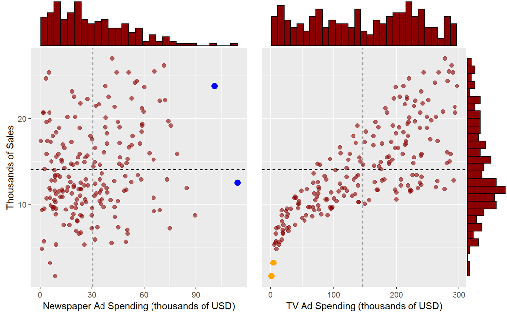

```r
## Plotting data

# Create Sales vs News Scatterplot
p.news <-
  ggplot(Plants, aes(x=Newspaper, y=Sales)) +
  geom_point(color="darkred", alpha=0.6, size=2)  +
  xlab("Newspaper Ad Spending (thousands of USD)") +
  ylab("Thousands of Sales")

# Some additional formatting of Sales vs News
p.news.hist <- p.news  +
  geom_point(data=Plants[Plants$Newspaper>90,], aes(x=Newspaper), color="blue", alpha=1,size=3)+
  geom_vline(xintercept=mean(Plants$Newspaper), linetype="dashed") + # Plot mean newspaper ad spending
  geom_hline(yintercept=mean(Plants$Sales), linetype="dashed") # Plot mean plant sales

# Put histograms of News in scatterplot Margins
p.news.hist <- ggMarginal(p.news.hist, type="histogram", fill="darkred",  margins = "x")

# Create Sales vs TV scatterplot
p.tv <-
  ggplot(Plants, aes(x=TV, y=Sales)) +
  geom_point(color="darkred", alpha=0.6, size=2) +
  xlab("TV Ad Spending (thousands of USD)") +
  theme(axis.title.y=element_blank(), axis.ticks.y=element_blank(), axis.text.y=element_blank())

# Some additional formatting of Sales vs TV
p.tv.hist <- p.tv +
  geom_point(data=Plants[Plants$Sales<4,], aes(x=TV), color="orange", alpha=1, size=3) +
  geom_vline(xintercept=mean(Plants$TV), linetype="dashed") + # Plot mean TV ad spending
  geom_hline(yintercept=mean(Plants$Sales), linetype="dashed") # Plot mean plant sales

# Put histograms of TV and Sales in scatterplot Margins
p.tv.hist <- ggMarginal(p.tv.hist, type="histogram", fill="darkred")

# Arrange plots in a 1 by 2 matrix
grid.arrange(p.news.hist, p.tv.hist, ncol=2)
```

`Sales` is slightly positively skewed with a mean of ~14,022 plants and a standard deviation of 5,220 plants.

`Newspaper` ad spending is positively skewed with a mean of $30,554 and a standard deviation of $21,800. The `Sales` vs `Newspaper` scatterplot actually appears quite random. If there truly is a relationship between the amount of money spent on newspaper advertisements and the houseplant sales for a campaign, it seems weak. There may be a weak, positive, linear relationship present. There are potentially 2 outliers in the `Newspaper` distribution, the campaigns that spent $114,000 and $100,900 on newspaper advertisements (blue points), but they don’t seem extreme. We’ll investigate them further when checking our assumptions for modeling.

# Q2

## Model 1: Newspaper Ad Spending as a Sales Predictor

First we look at the amount of money a campaign spends on newspaper advertising, `Newspaper`, as a linear predictor of the amount of houseplant sales for a campaign, `Sales`. The model creation and summary output is shown below.

```r
# Create SLR model with newspaper ad spending predicting plant sales
Model1 <- ols_regress(data=Plants, object=Sales~Newspaper)
Model1 # Display model summary
```

```
##                         Model Summary
## --------------------------------------------------------------
## R                       0.228       RMSE                5.092
## R-Squared               0.052       Coef. Var          36.316
## Adj. R-Squared          0.047       MSE                25.933
## Pred R-Squared          0.030       MAE                 4.147
## --------------------------------------------------------------
##  RMSE: Root Mean Square Error
##  MSE: Mean Square Error
##  MAE: Mean Absolute Error
##
##                                 ANOVA
## ---------------------------------------------------------------------
##                 Sum of
##                Squares         DF    Mean Square      F         Sig.
## ---------------------------------------------------------------------
## Regression     282.344          1        282.344    10.887    0.0011
## Residual      5134.805        198         25.933
## Total         5417.149        199
## ---------------------------------------------------------------------
##
##                                   Parameter Estimates
## ----------------------------------------------------------------------------------------
##       model      Beta    Std. Error    Std. Beta      t        Sig      lower     upper
## ----------------------------------------------------------------------------------------
## (Intercept)    12.351         0.621                 19.876    0.000    11.126    13.577
##   Newspaper     0.055         0.017        0.228     3.300    0.001     0.022     0.087
## ----------------------------------------------------------------------------------------
```

The linear model above gives us the following equation:

$$\frac{\widehat{\text{Sales}}}{1,000}= 12.351 + (0.055) \times \left(\frac{\text{Newspaper Spending}}{1,000} \right)$$

or

$$\widehat{\text{Sales}}= 12,351 + (0.055) \times \left(\text{Newspaper Spending} \right)$$

Where “Sales” is the number of plants sold during a campaign and “Newspaper Spending” is the amount of USD spent on newspaper advertising for a campaign (same units for both equations). Note that “Sales” and “Newspaper” are divided by 1,000 in the first equation because the units of the variables used to create the model were in thousands. Both equations are the same, and both equations take raw values for spending and sales.

For every additional $1 the company spends on newspaper advertising for a campaign, we expect houseplant sales to increase by 0.055 plants. In other words, for every additional $1,000 the company spends on newspaper advertising for a campaign, we expect to sell an additional 55 houseplants. For a campaign in which the company spends no money on newspaper advertisements, we expect to sell 12,351 plants.

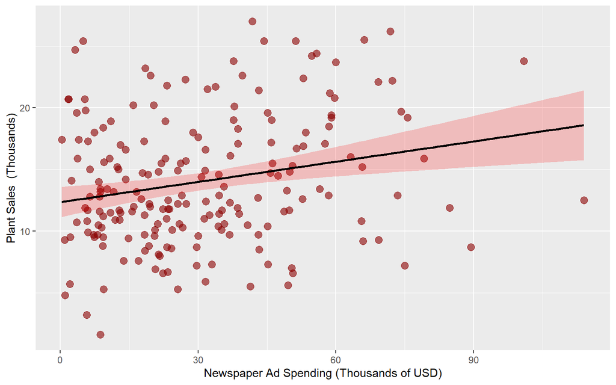

```r
# Plot Newspaper vs Sales with its regression line
ggplot(data=Plants, aes(x=Newspaper, y=Sales)) +
  geom_point(color="darkred", alpha=0.6, size=3) +
  geom_smooth(method="lm", color="black", fill="red", formula=y~x, alpha=0.2) + # Plot regression line
  ylab("Plant Sales  (Thousands)") +
  xlab("Newspaper Ad Spending (Thousands of USD)")
```

## Model 2: TV Ad Spending as a Sales Predictor

Now we look at the amount of money a campaign spends on TV advertising, `TV`, as a linear predictor of the amount of houseplant sales for a campaign, `Sales`. The model creation and summary output is shown below.

```r
# Create SLR model with TV ad spending predicting plant sales
Model2 <- ols_regress(data=Plants, object=Sales~TV)
Model2 # Display model summary
```

```
##                         Model Summary
## --------------------------------------------------------------
## R                       0.782       RMSE                3.259
## R-Squared               0.612       Coef. Var          23.239
## Adj. R-Squared          0.610       MSE                10.619
## Pred R-Squared          0.603       MAE                 2.550
## --------------------------------------------------------------
##  RMSE: Root Mean Square Error
##  MSE: Mean Square Error
##  MAE: Mean Absolute Error
##
##                                 ANOVA
## ----------------------------------------------------------------------
##                 Sum of
##                Squares         DF    Mean Square       F         Sig.
## ----------------------------------------------------------------------
## Regression    3314.618          1       3314.618    312.145    0.0000
## Residual      2102.531        198         10.619
## Total         5417.149        199
## ----------------------------------------------------------------------
##
##                                  Parameter Estimates
## -------------------------------------------------------------------------------------
##       model     Beta    Std. Error    Std. Beta      t        Sig     lower    upper
## -------------------------------------------------------------------------------------
## (Intercept)    7.033         0.458                 15.360    0.000    6.130    7.935
##          TV    0.048         0.003        0.782    17.668    0.000    0.042    0.053
## -------------------------------------------------------------------------------------
```

The linear model above gives us the following equation:

$$\frac{\widehat{\text{Sales}}}{1,000}= 7.033 + (0.048) \times \left(\frac{\text{TV Spending}}{1,000} \right)$$

or

$$\widehat{\text{Sales}}= 7,033 + (0.048) \times \left(\text{TV Spending} \right)$$

Where “Sales” is the number of plants sold during a campaign and “TV Spending” is the amount of USD spent on TV advertising for a campaign (same units for both equations). Again, “Sales” and “TV” are divided by 1,000 in the first equation because the units of the variables used to create the model were in thousands. Both equations are the same, and both equations take raw values for spending and sales.

For every additional $1 the company spends on TV advertising for a campaign, we expect houseplant sales to increase by 0.048 plants. In other words, for every additional $1,000 the company spends on TV advertising for a campaign, we expect to sell an additional 48 houseplants. For a campaign in which the company spends no money on TV advertisements, we expect to sell 7,033 plants.

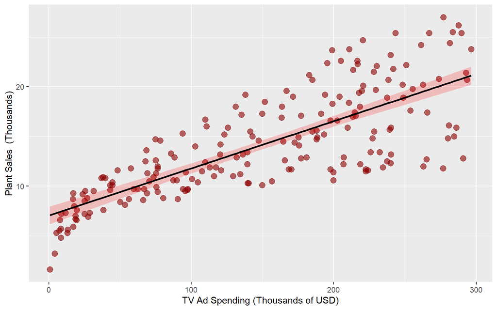

```r
# Plot TV vs Sales with its regression line
ggplot(data=Plants, aes(x=TV, y=Sales)) +
  geom_point(color="darkred", alpha=0.6, size=3) +
  geom_smooth(method="lm", color="black", fill="red", formula=y~x, alpha=0.2) + # Plot regression line
  ylab("Plant Sales  (Thousands)") +
  xlab("TV Ad Spending (Thousands of USD)")
```

# Q3

We see a greater increase in sales when we spend more money on newspaper advertising, 55 more sales for $1,000 extra on newspaper ads, than when we spend more money on TV advertising, 48 more sales for $1,000 extra on TV ads. This is according to the slopes from `Model1` and `Model2` respectively.

Even though `Model1` (newspaper predictor) has a larger slope, there is much more uncertainty in our estimate for the true slope of the line predicting sales from newspaper ad spending than our estimate in the true slope of the line predicting sales from TV ad spending. For every additional $1,000 spent on newspaper ads we are 95% confident that we can expect 22 to 87 more houseplant sales. For every additional $1,000 spent on TV ads we are 95% confident that we can expect 42 to 53 more houseplant sales. This is according the the upper and lower bounds of the 95% confidence intervals given in the models’ summary outputs.

The return on investment for spending money on newspaper ads could truly be much lower or much higher than what this particular model estimates. But the full range of plausible slopes for `Model2` (TV predictor) could be entirely within what the company sees as a modest return for their spending. The company must decide what they are willing to risk.

`Model2` (TV predictor) explains much more variability in `Sales` than `Model1` (newspaper predictor). According to the $R^2$ values listed in the models’ summary outputs, 61.2% of the variation in plant sales is accounted for by variation in TV ad spending, whereas only 5.2% of the variation in plant sales is accounted for by variation in newspaper ad spending.

# Q4

We’ll conduct a one sided t-test for the true intercept of the population line predicting plant sales from newspaper ad spending. Recall that the units of our model is in thousands, so we scale the population parameters in our hypotheses accordingly. We are okay with incorrectly rejecting $H_0$ (1/25)= 4% of the time, so we set a significnce level of $\alpha$ = 0.04 . Let’s remind ourselves of the model summary:

```r
# Display model summary for Sales~Newspaper
Model1
```

```
##                         Model Summary
## --------------------------------------------------------------
## R                       0.228       RMSE                5.092
## R-Squared               0.052       Coef. Var          36.316
## Adj. R-Squared          0.047       MSE                25.933
## Pred R-Squared          0.030       MAE                 4.147
## --------------------------------------------------------------
##  RMSE: Root Mean Square Error
##  MSE: Mean Square Error
##  MAE: Mean Absolute Error
##
##                                 ANOVA
## ---------------------------------------------------------------------
##                 Sum of
##                Squares         DF    Mean Square      F         Sig.
## ---------------------------------------------------------------------
## Regression     282.344          1        282.344    10.887    0.0011
## Residual      5134.805        198         25.933
## Total         5417.149        199
## ---------------------------------------------------------------------
##
##                                   Parameter Estimates
## ----------------------------------------------------------------------------------------
##       model      Beta    Std. Error    Std. Beta      t        Sig      lower     upper
## ----------------------------------------------------------------------------------------
## (Intercept)    12.351         0.621                 19.876    0.000    11.126    13.577
##   Newspaper     0.055         0.017        0.228     3.300    0.001     0.022     0.087
## ----------------------------------------------------------------------------------------
```

$H_0$: $\beta_0=8$  
The true number of plant sales for a campaign that spends no money on newspaper advertising is 8,000.

We compute the test statistic using the `Model1` intercept $b_0=12.351$ and the `Model1` standard error of the intercept $se(b_0)=0.621$.

$t^* = \frac{b_0 - \beta_0}{se( \beta_0 )} = \frac{12.351-8}{0.621}=7.006441$

We find the probability of seeing a sample intercept of 12.351 or more extreme given that the population intercept is truly 8 with a t-distribution with $n-2$ degrees of freedom.

```r
# P-value calculation
pt( 7.006441, df=nrow(Plants)-2, lower.tail=FALSE)
```

```
## [1] 1.869625e-11
```

p-value = $P(|t|>t^*) \approx 1.87 \times 10^{-11}\approx 0$

We reject $H_0$. With a p-value of $p\approx0<0.04=\alpha$ we have strong evidence to suggest that campaigns that spend no money on newspaper advertisements result in more than 8,000 plant sales. The probability of our sample giving us an estimate of 12,351 plant sales for campaigns that spend no money on newspaper ads when the true number of sales for such a campaign is 8,000 is almost 0%.

The data suggests that even if the company spends no money on newspaper advertisements they will probably still be able to sell all 8,000 of their lilies. It is OK for the company not to advertise in newspapers. If our client is not a part of the company from which we got our data, we should be cautious abotu extended this conclusion to them.

# Q5

We’ll conduct an ANOVA F-test for the linear relationship between plant sales and TV ad spending. Recall that the units of our model is in thousands, so we scale the population parameters in our hypotheses accordingly. We set a significance level of $\alpha$ = 0.01 . Let’s remind ourselves of the ANOVA table for Model2:

```r
# Display ANOVA table for Sales~TV
anova(Model2$model)
```

```
## Analysis of Variance Table
##
## Response: Sales
##            Df Sum Sq Mean Sq F value    Pr(>F)
## TV          1 3314.6  3314.6  312.14 < 2.2e-16 ***
## Residuals 198 2102.5    10.6
## ---
## Signif. codes:  0 '***' 0.001 '**' 0.01 '*' 0.05 '.' 0.1 ' ' 1
```

$H_0$: $\beta_1 = 0$  
There is no linear relationship between plant sales and TV ad spending.

$H_A$: $\beta_1 \neq 0$  
There is a linear relationship between plant sales and TV ad spending.

We can find the F-statistic, a ratio between the Mean Squared Regression and Mean Squared Error, from the ANOVA table in the `Model2` output above.

$F^* = \frac{MSR}{MSE} = \frac{3314.6}{10.6} \approx 312.14$

The probability of seeing an F-statistic of 312.14 or more given that there is truly no linear relationship between plant sales and TV ad spending is listed under the last column of the ANOVA table in the Model2 output. $P(F>F^*) \approx 0$

We reject $H_0$. With a p-value of $p\approx0<0.01=\alpha$ we have strong evidence to suggest that there is a linear relationship between the amount of money a campaign spends on TV advertisements and the campaign’s number of plant sales. The probability of our sample giving us an estimate of 48 plant sales for every $1,000 spent on TV advertising if there were truly no linear relationship between spending and sales is almost 0%.

# Q6

To build a prediction interval for the range of plausible plant sale values for a campaign for the lesser-variated-monstera-fig based off of its popularity, we first need to build a linear model with `Plant_Popularity` as a predictor of `Sales`.

```r
# Build SLR model with % Plant popularity as a predictor of thousands of sales
Model3 <- ols_regress(Sales~Plant_Popularity, data=Plants)
Model3 # Model Summary
```

```
##                         Model Summary
## --------------------------------------------------------------
## R                       0.586       RMSE                4.240
## R-Squared               0.343       Coef. Var          30.239
## Adj. R-Squared          0.340       MSE                17.980
## Pred R-Squared          0.332       MAE                 3.447
## --------------------------------------------------------------
##  RMSE: Root Mean Square Error
##  MSE: Mean Square Error
##  MAE: Mean Absolute Error
##
##                                 ANOVA
## ----------------------------------------------------------------------
##                 Sum of
##                Squares         DF    Mean Square       F         Sig.
## ----------------------------------------------------------------------
## Regression    1857.119          1       1857.119    103.288    0.0000
## Residual      3560.030        198         17.980
## Total         5417.149        199
## ----------------------------------------------------------------------
##
##                                     Parameter Estimates
## -------------------------------------------------------------------------------------------
##            model     Beta    Std. Error    Std. Beta      t        Sig      lower    upper
## -------------------------------------------------------------------------------------------
##      (Intercept)    0.575         1.357                  0.424    0.672    -2.100    3.251
## Plant_Popularity    0.396         0.039        0.586    10.163    0.000     0.319    0.473
## -------------------------------------------------------------------------------------------
```

```r
# create a data frame with the values we want predictions for
lvmfig <- data.frame(Plant_Popularity=c(90))
# Get and display predictions
predict(Model3$model, newdata=lvmfig, interval="predict", level=0.99)
```

```
##        fit      lwr      upr
## 1 36.20521 23.77691 48.63351
```

# Q7

To determine whether the following SLR assumptions hold for the errors $\varepsilon_i$ of `Model1` and `Model2`:

- There is a **linear** relationship between the mean responses at each value of the predictor
- The errors are **independent**
- The errors are **Normally distributed**
- The errors have **equal variance**

we’ll examine the residuals $e_i$ of the respective models. We’ll also take a closer look at the potential outliers mentioned earlier in the report.

## Model1 - Linearity

Here is the scatterplot of `Newspaper` as a predictor of `Sales` from earlier, excluding the histogram.

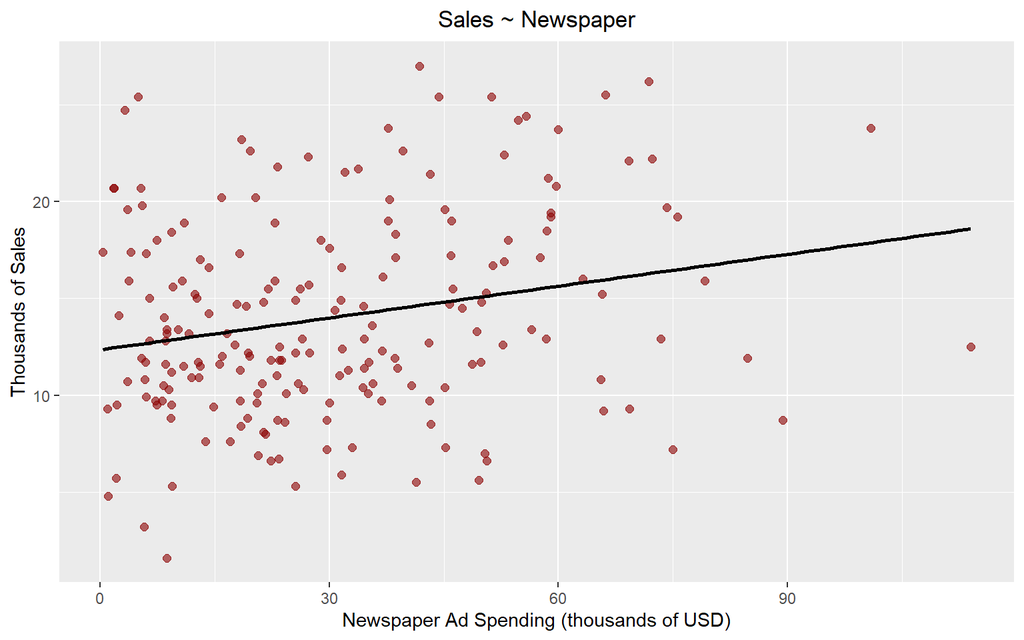

```r
p.news +
  geom_smooth(method="lm", color="black", fill="red", formula=y~x, alpha=0) +  # Plot regression line without confidence interval
  theme(plot.title = element_text(hjust = 0.5)) +
  ggtitle("Sales ~ Newspaper")
```

We can make out a positive linear relationship. Let’s look at Residuals versus Fit plot for `Model1`, which predicted `Sales` from `Newspaper`.

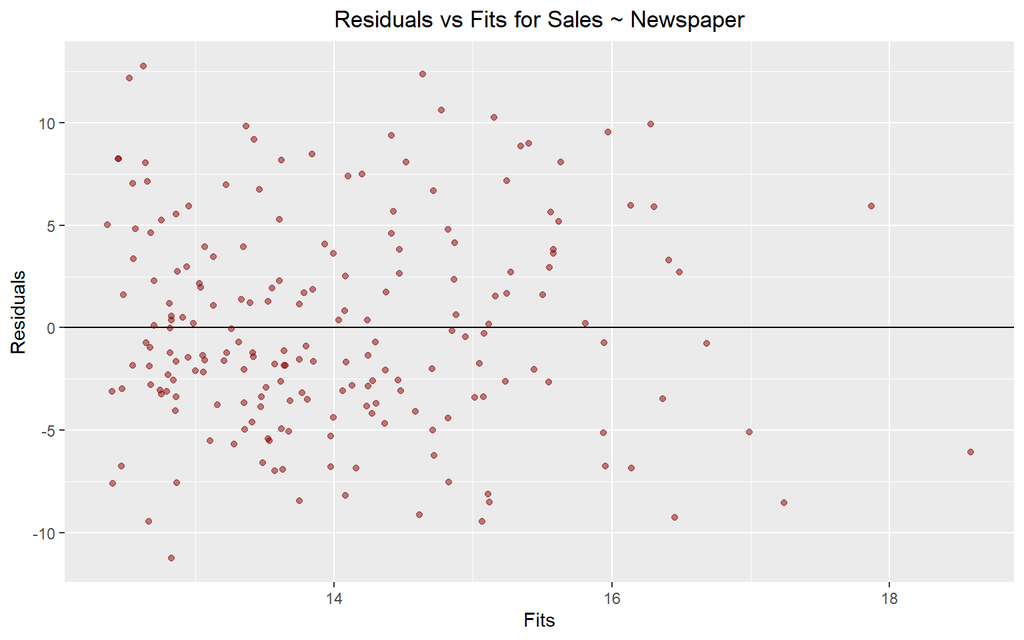

```r
# Foundation of a residuals vs fits plot
p.rvf <-
  ggplot(Plants) +
  geom_hline(yintercept=0) +
  xlab("Fits") +
  ylab("Residuals") +
  theme(plot.title = element_text(hjust = 0.5))

# Since we used ols_regress() instead of lm() we must first access the model object, then get the residuals and the fits
Plants$M1r <- Model1$model$residuals
Plants$M1f <- Model1$model$fitted.values

# Plot Model1's residuals and fits
p.rvf1 <-
  p.rvf + geom_point(data=Plants, aes(x=M1f, y=M1r), color="darkred", alpha=0.5) +
  ggtitle("Residuals vs Fits for Sales ~ Newspaper")

# Display plot
p.rvf1
```

The residuals seem to bounce randomly about the line $e$=0. There are no patterns present in this plot of `Model1`’s Residuals vs Fits. We can assume that the errors $\varepsilon_i$ follow the same behavior and that the linearity condition is satisfied.

## Model1 - Independence

If the company has any information available about the order that these campaigns were run, it would be worth considering serial correlation between the campaigns. Since we don’t have that data at the moment, we’ll consider interactions between the 5 covariates in our data set.

Below is a correlation and scatterplot matrix for all of the variables in the `Plants` data set. We’ve also included the `Model1` residuals in the row/column labeled `M1r` so that the last row of the matrix is comprised entirely of Residuals vs Predictor plots. We’ll refer to the entries in the matrix below with (row, column) indexing.

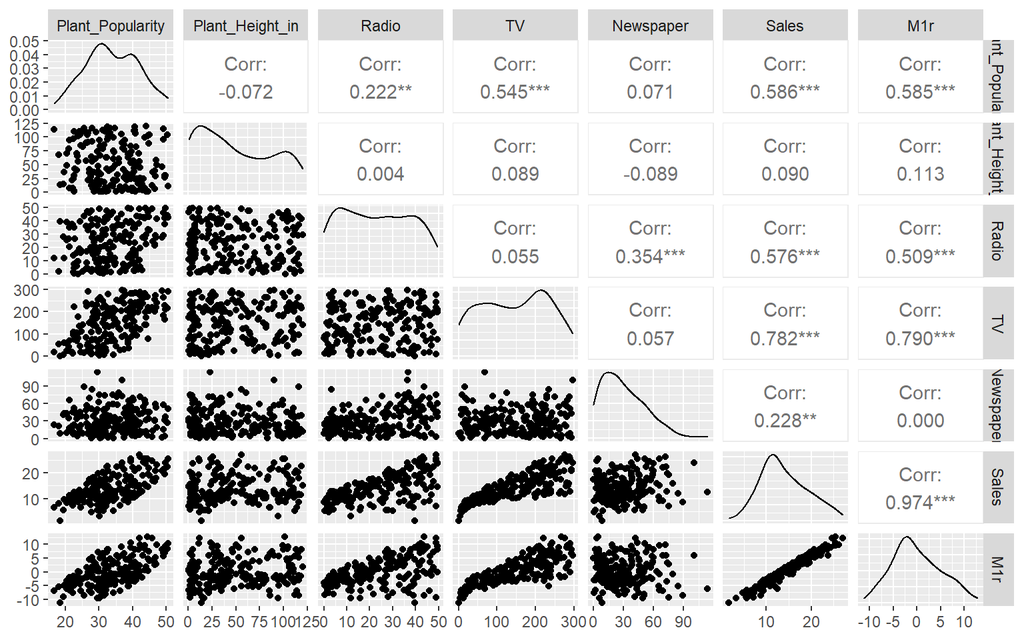

```r
# Correlation matrix for everything except the model 1 fits column
ggpairs( Plants[, -which(names(Plants) == "M1f")] )
```

From the Residuals vs Predictor row of our matrix, we see a pattern in the `TV`, `Plant_popularity`, and `Radio` columns. These are potentially confounding variables. Since statistical tests and intervals are sensitive to violation of the independence condition, we should look into the features discussed below before making any formal conclusions from our model.

In the (`Sales`,`Radio`) entry we see that the plot of `Sales` and `Radio` indicates a positive linear relationship between the two variables. The plot also appears heteroscedastic. The Residuals vs Predictor plot in the (`M1r`, `Radio`) entry we see the same pattern. In the (`Radio`, `Sales`) entry, we see that they have a statistically significant correlation of 0.576. We may be able to improve our model by including the `Radio` variable, but the heteroscedasticity of its relationship with `Sales` and the possible interaction between `Newspaper` and `Radio` (see (`Radio`,`Newspaper`) entry) should be investigated first.

Below is a closer look at the Residuals vs Predictor plots for each potential confounding variable in relation to `Newspaper` and `Sales`. All plots share the same y-axis. The coloring below has no meaning, it is only to make the plots visually distinct from each other.

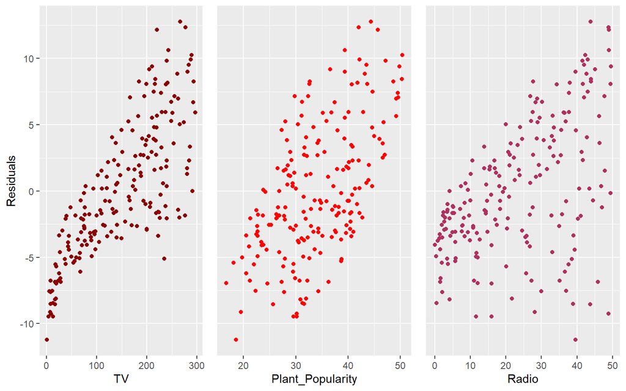

```r
# Residuals vs Predictor plots

# TV predictor
p.news.tv <-
  Plants %>%
  ggplot( aes(x=TV, y=M1r)) +
  geom_point(color="darkred") +
  ylab("Residuals")

# Popularity predictor
p.news.pop <-
  Plants %>%
  ggplot( aes(x=Plant_Popularity, y=M1r)) +
  geom_point(color="red") +
  theme(axis.title.y=element_blank(), axis.ticks.y=element_blank(), axis.text.y=element_blank())

# Radio predictor
p.news.rad <-
  Plants %>%
  ggplot( aes(x=Radio, y=M1r)) +
  geom_point(color="maroon") +
  theme(axis.title.y=element_blank(), axis.ticks.y=element_blank(), axis.text.y=element_blank())

# Display plots in a 1 by 3 matrix
grid.arrange(p.news.tv, p.news.pop, p.news.rad, ncol=3)
```

## Model1 - Normal

In our residuals’ QQ plot, the slight dip in the center and the deviation from linearity at the extreme values indicate that the distribution of our residuals is slightly more skewed and contains more extreme data points than a Normal distribution. Both of these features are reflected in the density plot and histogram on the right.

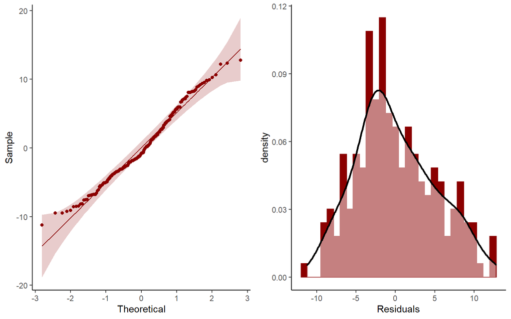

```r
# Create QQ plot of residuals
p.m1.qq <- ggqqplot(Plants$M1r, color="darkred", lwd=2) + theme_classic()

# Create histogram of residuals
p.m1.rhist <- ggplot(Plants, aes(x=M1r)) +
  geom_histogram(aes(y = ..density..), color = "darkred", fill = "darkred") +
  geom_density(alpha = .5, fill = "white", size=1) + theme_classic() + # Plot density curve over histogram
  xlab("Residuals")

# Display plots
grid.arrange(p.m1.qq, p.m1.rhist, ncol=2)
```

```r
# Conduct tests for normality of the residuals
ols_test_normality(Model1$model)
```

```
## -----------------------------------------------
##        Test             Statistic       pvalue
## -----------------------------------------------
## Shapiro-Wilk              0.982          0.0114
## Kolmogorov-Smirnov        0.0797         0.1577
## Cramer-von Mises          15.998         0.0000
## Anderson-Darling          1.1601         0.0048
## -----------------------------------------------
```

Out of the 4 tests for Normality, only the Kolmogorov-Smirnov test results in a failure to reject the assumption that our data is normal with $\alpha=0.05$. The majority consensus of the other hypothesis tests is that we can reject the null hypothesis that our residuals are normally distributed. However, from looking at the plots we see that the skew of the data isn’t too extreme. We also have a decently large sample size of 200, so slight deviations from normality may not be of too much concern here. We may not have perfectly normal residuals but it is not of enough consequence to render `Model1` unusable.

## Model1 - Equal Variance

Again, we look at a Residuals vs. Fits plot. There is no fanning, funneling, or other systematic pattern present in this plot. All of the residuals seem to fall in a horizontal band around the line $e$=0. We have met the equal variance condition.

While we’re discussing variance, we can revisit the potential outliers discussed earlier (shown larger in blue). There are no individual points that look particularly out of place in this plot. The blue points fall within the same rectangular band around $e$=0, as the rest of the residuals. These points don’t seem problematic.

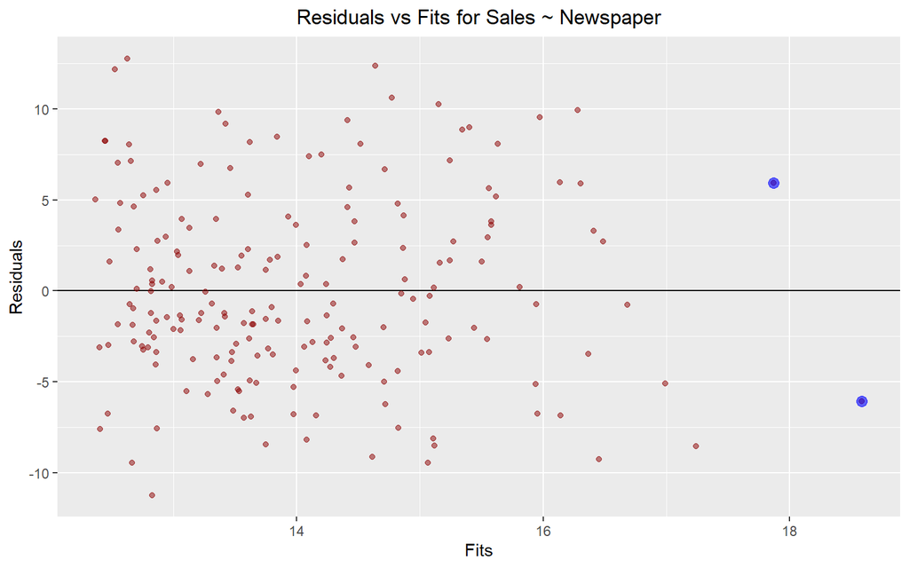

```r
# Display Residuals vs fits, color potential outliers blue
p.rvf1 + geom_point(data=Plants[Plants$Newspaper>90,], aes(x=M1f, y=M1r), color="blue", alpha=0.6, size=3)
```

## Model2 - Linearity

Here is the scatterplot of `TV` as a predictor of `Sales` from earlier, excluding the histogram.

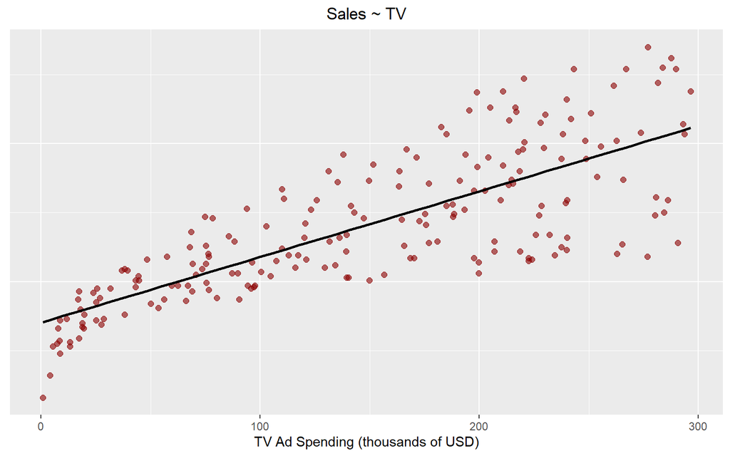

```r
p.tv +
  geom_smooth(method="lm", color="black", fill="red", formula=y~x, alpha=0) +  # Plot regression line without confidence interval +
  theme(plot.title = element_text(hjust = 0.5)) +
  ggtitle("Sales ~ TV")
```

There is clearly a strong positive relationship here, but it does not look linear. Let’s look at Residuals versus Fit plot for `Model2`, which predicted `Sales` from `TV`.

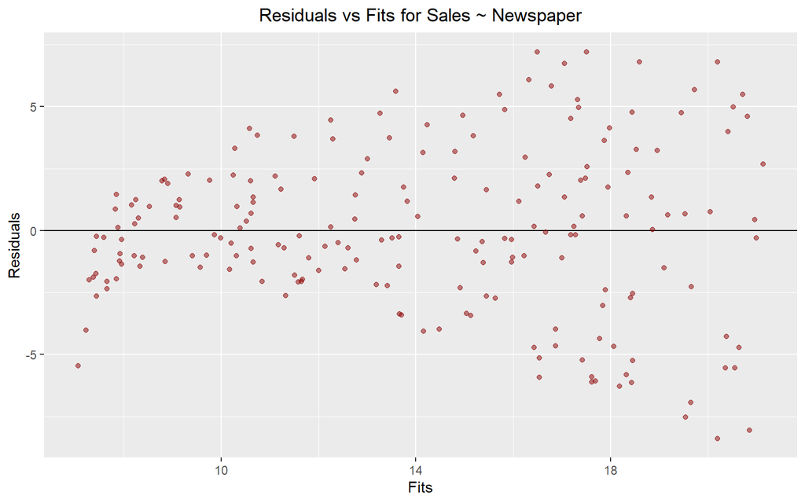

```r
# Get Model2's residuals and fits
Plants$M2r <- Model2$model$residuals
Plants$M2f <- Model2$model$fitted.values

# Plot Model2's residuals and fits
p.rvf2 <-
  p.rvf + geom_point(data=Plants, aes(x=M2f, y=M2r), color="darkred", alpha=0.5) +
  ggtitle("Residuals vs Fits for Sales ~ Newspaper")

# Display Plot
p.rvf2
```

The residuals do not fall randomly about the line $e$=0. There is a curved hook-like pattern present in this plot of `Model2`’s Residuals vs Fits. The presence of a systematic deviation from randomness in this plot confirms what we directly observed in the scatterplot. The linearity condition is not satisfied here.

## Model2 - Independence

Again, it would be worth considering serial correlation between the campaigns but here we simply consider interactions between the 5 covariates in our data set.

Below is the same correlation and scatterplot matrix as before, except now we include the residuals from `Model2` where `TV` predicts `Sales`. The `M2r` row now contains Residuals vs Predictor plots.

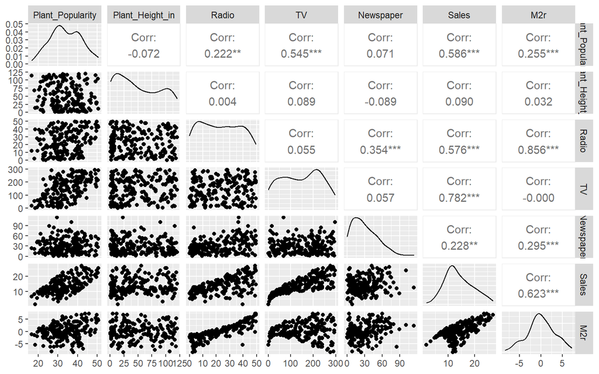

```r
# drop these columns
drop = c("M1f", "M1r", "M2f")
# Plot correlation matrix
ggpairs( Plants[, !names(Plants) %in% drop])
```

From the Residuals vs Plots row of our matrix, we see a pattern in the `Radio` and `Plant_popularity` columns. These are potentially confounding variables. We should look into the features discussed below before making any formal conclusions from our model.

Looking at the (`Sales`,`Radio`) entry, we see that the relationship between the two looks positive and linear as previously noted. Looking at the (`TV`,`Radio`) entry, we see no apparent relationship between the two, so there’s no indication of an interaction occurring strictly between those variables. `Radio` seems like it is independently affecting `Sales` rather than confounding the effect of `TV` on `Sales`. The (`M2r`,`Radio`) entry, which is the Residuals vs Predictor plot for the `Radio` variable, shows a positive, linear trend. We might be able to make a better model by including the `Radio` variable as a predictor.

Like before, `Sales` and `Plant_Popularity` seem to have a strong positive linear relationship with a statistically significant correlation of 0.586. The Residuals vs Predictor plot in the (`M2r`, `Plant_Popularity`) entry also appears to have a positive linear pattern. There is also a moderately strong, positive, linear relationship between `Plant_Popularity` and `TV` as demonstrated by the (`TV`,`Plant_Popularity`) plot and the statistically significant correlation of 0.545 in (`Plant_Popularity`,`TV`). It seems `Plant_Popularity` is a confounding variable in this model. It seems likely that plants for campaigns which received more TV advertising would become more popular, or that the company was willing to spend more on the TV advertisement of already popular plants. The potentially synergistic relationship between these variables could explain the heteroscedasticity of `TV~Sales` and should be further considered and included in a new model.

Below is a closer look a the Residuals vs Predictor plots for each potential confounding variable in relation to `TV` and `Sales`. All plots share the same y-axis. The coloring below has no meaning, it is only to make the plots visually distinct from each other.

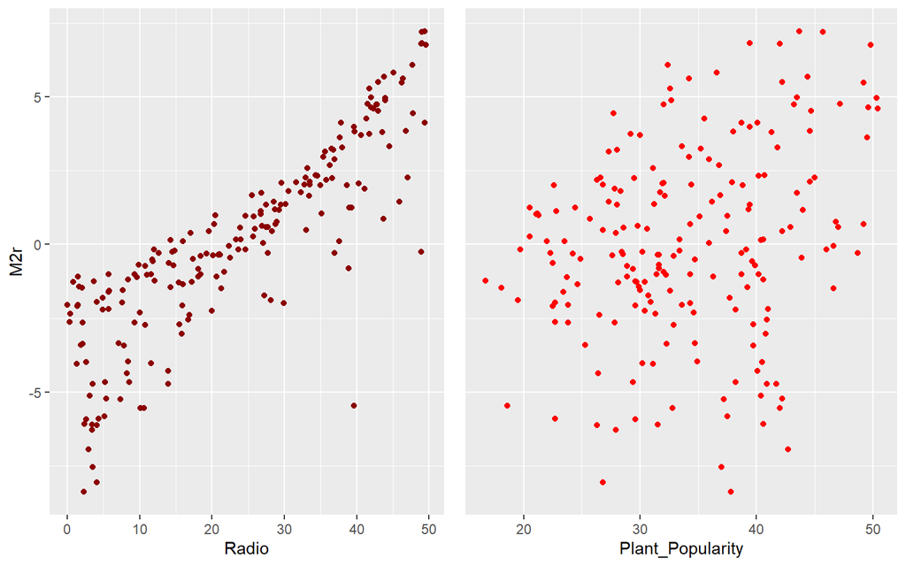

```r
# Residuals vs Predictor plots

# TV predictor
p.tv.rad <-
  Plants %>%
  ggplot( aes(x=Radio, y=M2r)) +
  geom_point(color="darkred")

# Popularity predictor
p.tv.pop <-
  Plants %>%
  ggplot( aes(x=Plant_Popularity, y=M2r)) +
  geom_point(color="red") +
  theme(axis.title.y=element_blank(), axis.ticks.y=element_blank(), axis.text.y=element_blank())

# Display in a 1 by 2 matrix
grid.arrange(p.tv.rad, p.tv.pop, ncol=2)
```

## Model2 - Normal

In our residuals’ QQ plot, the deviation from the linear pattern at the extreme values indicate that the distribution of our residuals has more data in its tails than a Normal distribution. The rest of the distribution seems approximately normal, which is reflected in the histogram on the right.

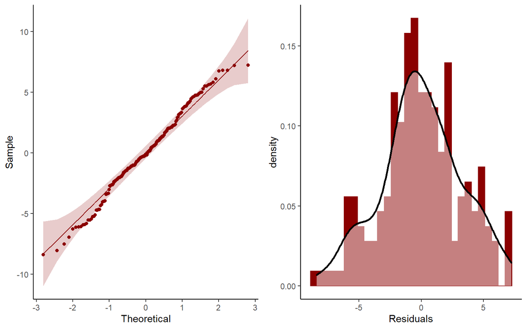

```r
# QQ plot of residuals
p.m2.qq <- ggqqplot(Plants$M2r, color="darkred", lwd=2) + theme_classic()

# Histogram of residuals
p.m2.rhist <- ggplot(Plants, aes(x=M2r)) +
  geom_histogram(aes(y = ..density..), color = "darkred", fill = "darkred") +
  geom_density(alpha = .5, fill = "white", size=1) + theme_classic() +
  xlab("Residuals")

# Arrange in a 1 by 2 matrix
grid.arrange(p.m2.qq, p.m2.rhist, ncol=2)
```

```r
# Conduct tests for normality of the residuals
ols_test_normality(Model2$model)
```

```
## -----------------------------------------------
##        Test             Statistic       pvalue
## -----------------------------------------------
## Shapiro-Wilk              0.9905         0.2133
## Kolmogorov-Smirnov        0.0415         0.8806
## Cramer-von Mises          14.211         0.0000
## Anderson-Darling          0.4912         0.2170
## -----------------------------------------------
```

## Model2 - Equal Variance

Again, we look at a Residuals vs. Fits plot. There is a clear fanning pattern present in this plot. The residuals do not fall randomly around the line $e$=0. We have not met the equal variance condition.

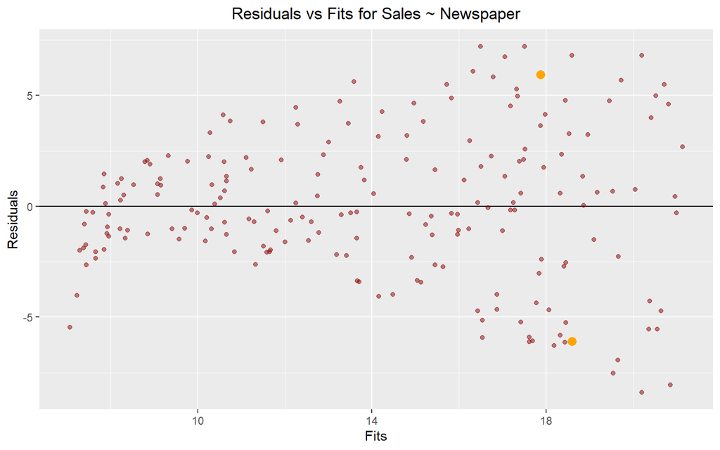

```r
# Residuals vs Fits plot, color potential outliers
p.rvf2 + geom_point(data=Plants[Plants$Newspaper>90,], aes(x=M1f, y=M1r), color="orange", alpha=1, size=3)
```

# Q8

Using multiple linear regression will allow our models use more variables to account for additional variation that these models couldn’t explain. Including more variables in a model may also account for patterns we saw in our residuals.